# P2_Shannon

Shannon Dickson

2022-09-21

# Packages

```r
library(ISLR)
library(tidyverse)
```

# Data

```r
# Get an idea of what the Hitters dataset looks like
head(Hitters)
```

```
##                   AtBat Hits HmRun Runs RBI Walks Years CAtBat CHits CHmRun
## -Andy Allanson      293   66     1   30  29    14     1    293    66      1
## -Alan Ashby         315   81     7   24  38    39    14   3449   835     69
## -Alvin Davis        479  130    18   66  72    76     3   1624   457     63
## -Andre Dawson       496  141    20   65  78    37    11   5628  1575    225
## -Andres Galarraga   321   87    10   39  42    30     2    396   101     12
## -Alfredo Griffin    594  169     4   74  51    35    11   4408  1133     19
##                   CRuns CRBI CWalks League Division PutOuts Assists Errors
## -Andy Allanson       30   29     14      A        E     446      33     20
## -Alan Ashby         321  414    375      N        W     632      43     10
## -Alvin Davis        224  266    263      A        W     880      82     14
## -Andre Dawson       828  838    354      N        E     200      11      3
## -Andres Galarraga    48   46     33      N        E     805      40      4
## -Alfredo Griffin    501  336    194      A        W     282     421     25
##                   Salary NewLeague
## -Andy Allanson        NA         A
## -Alan Ashby        475.0         N
## -Alvin Davis       480.0         A
## -Andre Dawson      500.0         N
## -Andres Galarraga   91.5         N
## -Alfredo Griffin   750.0         A
```

# Examples

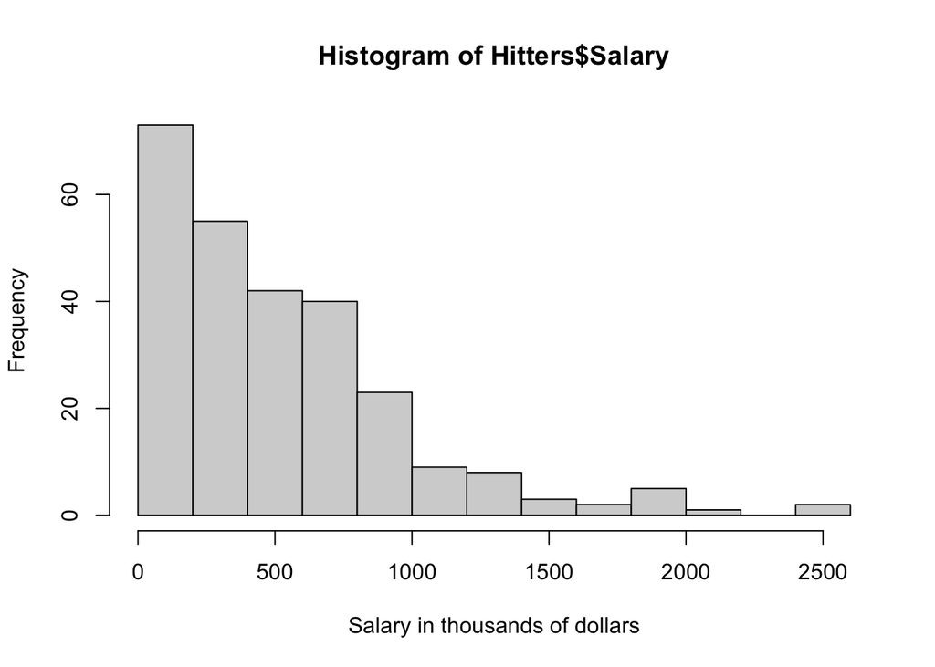

```r
# histogram of the distribution of salary
hist(Hitters$Salary, xlab = "Salary in thousands of dollars")
```

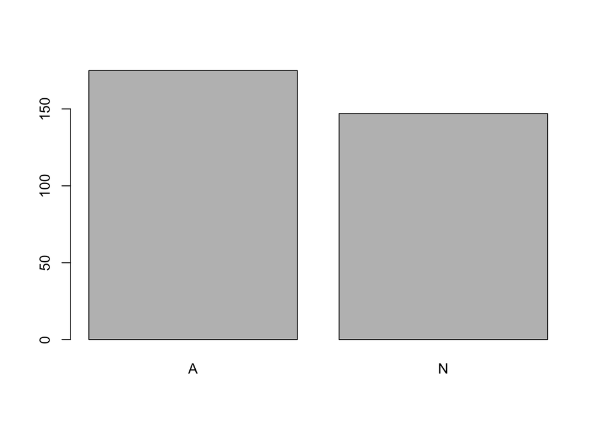

```r
# barplot of how many members in each league
barplot(table(Hitters$League))
```

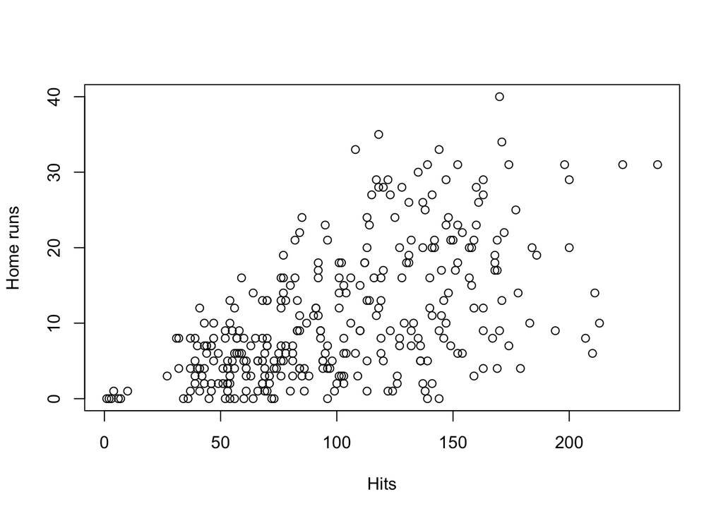

```r
# number of career home runs vs 1986 home runs
plot(x = Hitters$Hits, y = Hitters$HmRun,
     xlab = "Hits", ylab = "Home runs")
```

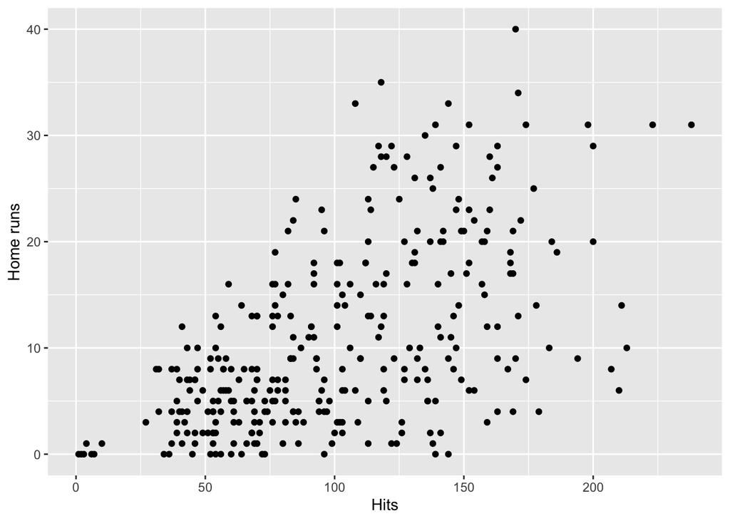

```r
homeruns_plot <-
  ggplot(Hitters, aes(x = Hits, y = HmRun)) +
  geom_point() +
  labs(x = "Hits", y = "Home runs")

homeruns_plot
```

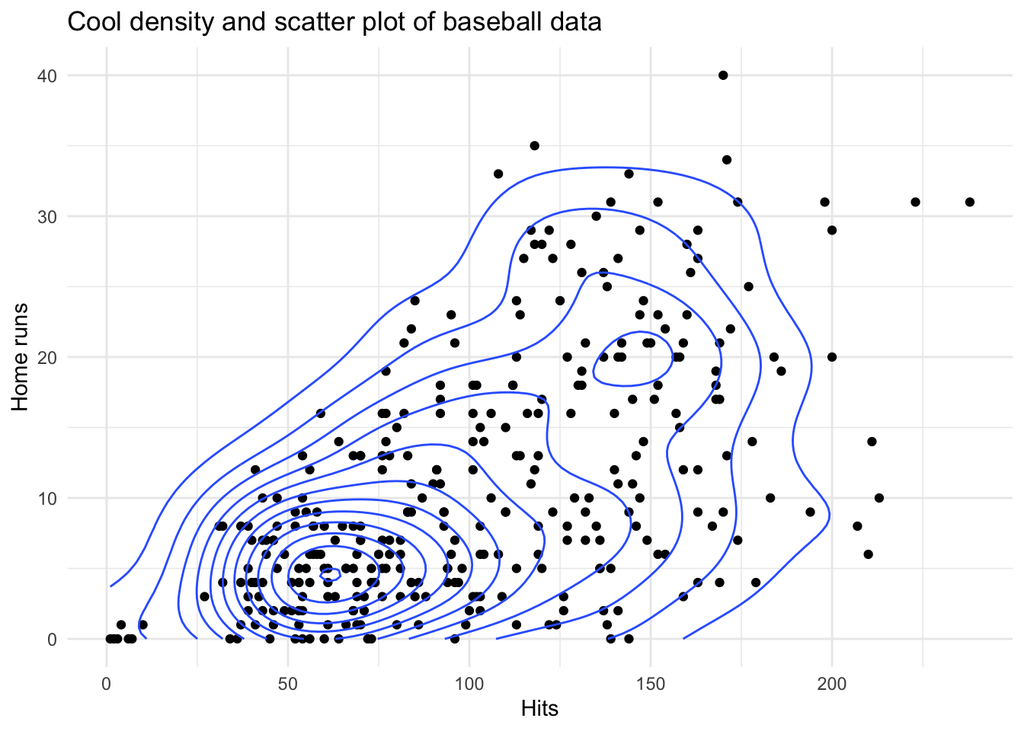

```r
homeruns_plot +
  geom_density_2d() +
  labs(title = "Cool density and scatter plot of baseball data") +
  theme_minimal()
```

# Exercises

**1. Name the aesthetics, geoms, scales, and facets of the above visualisation. Also name any statistical transformations or special coordinate systems.**

Aesthetics:

- Number of hits on the x-axis
- Number of home runs on the y-axis

Geoms:

- Points
- Contour lines

Scales:

- Continuous variable on the x-axis
- Continuous variable on the y-axis

## Aesthetics and data preparation

**2. Run the code below to generate data. There will be three vectors in your environment. Put them in a data frame for entering it in a `ggplot()` call using either the `data.frame()` or the `tibble()` function. Give informative names and make sure the types are correct (use the `as.<type>()` functions). Name the result `gg_students.`**

```r
set.seed(1234)
student_grade  <- rnorm(32, 7)
student_number <- round(runif(32) * 2e6 + 5e6)
programme      <- sample(c("Science", "Social Science"), 32, replace = TRUE)
```

```r
# I use tibble because they make life easier, especially in tidyverse
gg_students <- tibble(number = as.character(student_number),
                      grade  = student_grade,
                      prog   = as.factor(programme))
# Check all is well
str(gg_students)
```

```
## tibble [32 × 3] (S3: tbl_df/tbl/data.frame)
##  $ number: chr [1:32] "5478051" "6412989" "5616190" "6017095" ...
##  $ grade : num [1:32] 5.79 7.28 8.08 4.65 7.43 ...
##  $ prog  : Factor w/ 2 levels "Science","Social Science": 2 1 2 2 2 1 1 1 1 2 ...
```

```r
# Look at it
head(gg_students)
```

```
## # A tibble: 6 × 3
##   number  grade prog
##   <chr>   <dbl> <fct>
## 1 5478051  5.79 Social Science
## 2 6412989  7.28 Science
## 3 5616190  8.08 Social Science
## 4 6017095  4.65 Social Science
## 5 5103293  7.43 Social Science
## 6 6129140  7.51 Science
```

**3. Plot the first homeruns_plot again, but map the Hits to the y-axis and the HmRun to the x-axis instead.**

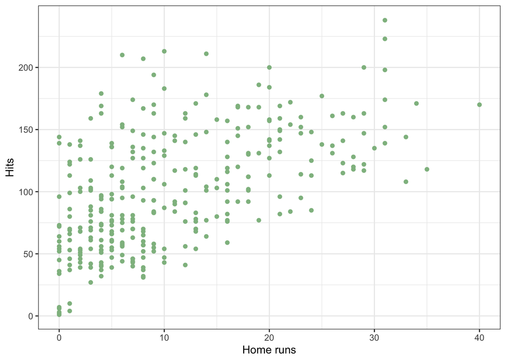

```r
Hitters %>%
  ggplot(aes(HmRun, Hits)) +
  geom_point(colour = "darkseagreen") +
  labs(y = "Hits", x = "Home runs") +
  theme_bw()
```

**4. Recreate the same plot once more, but now also map the variable League to the colour aesthetic and the variable Salary to the size aesthetic.**

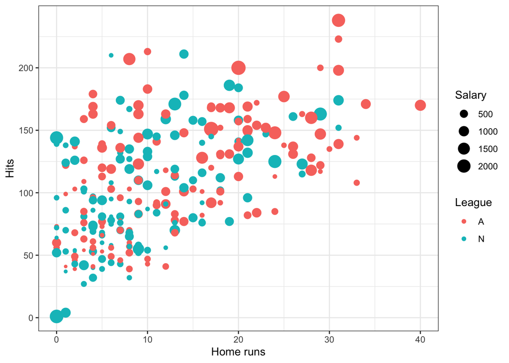

```r
Hitters %>%
  ggplot(aes(HmRun, Hits, colour = League, size = Salary)) +
  geom_point() +
  labs(y = "Hits", x = "Home runs") +
  theme_bw()
```

## Geoms

**5. Look at the many different geoms on the reference website.**

There is a lot.

## Visual exploratory analysis

### Histogram

**6. Use geom_histogram() to create a histogram of the grades of the students in the gg_students dataset. Play around with the binwidth argument of the geom_histogram() function.**

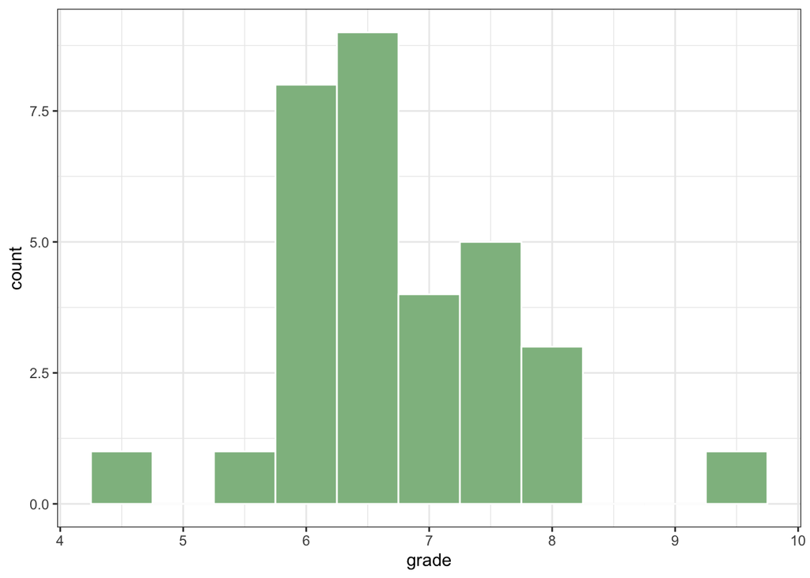

```r
gg_students %>%
  ggplot(aes(grade)) +
  geom_histogram(binwidth = .5, fill = "darkseagreen", colour = "white") +
  theme_bw()
```

### Density

**7. Use geom_density() to create a density plot of the grades of the students in the gg_students dataset. Add the argument fill = “light seagreen” to geom_density().**

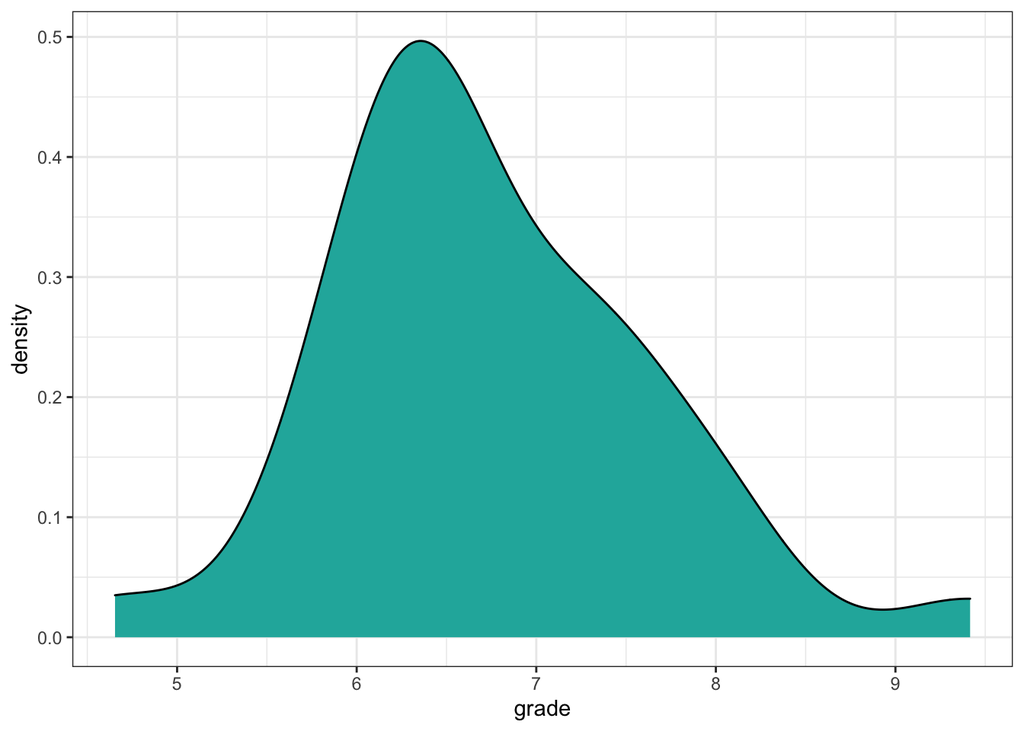

```r
gg_students %>%
  ggplot(aes(grade)) +
  geom_density(fill = "light seagreen") +
  theme_bw()
```

**8. Add rug marks to the density plot through geom_rug(). You can edit the colour and size of the rug marks using those arguments within the geom_rug() function.**

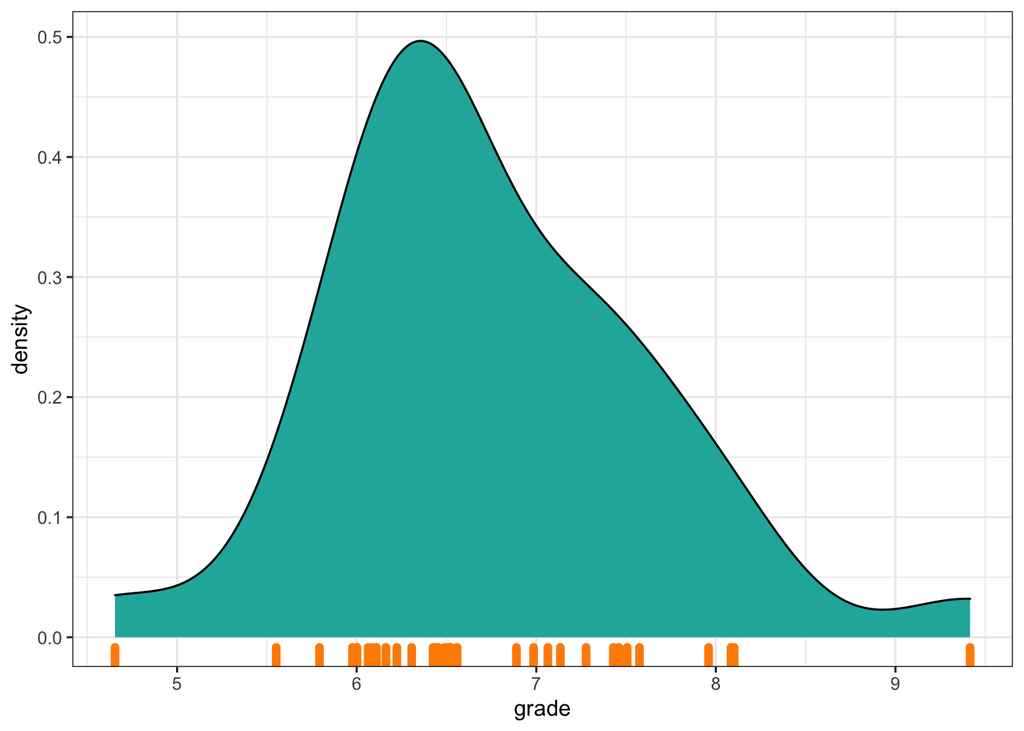

```r
gg_students %>%
  ggplot(aes(grade)) +
  geom_density(fill = "light seagreen") +
  geom_rug(size = 2, colour = "darkorange") +
  theme_bw()
```

**9. Increase the data to ink ratio by removing the y axis label, setting the theme to theme_minimal(), and removing the border of the density polygon. Also set the limits of the x-axis to go from 0 to 10 using the xlim() function, because those are the plausible values for a student grade.**

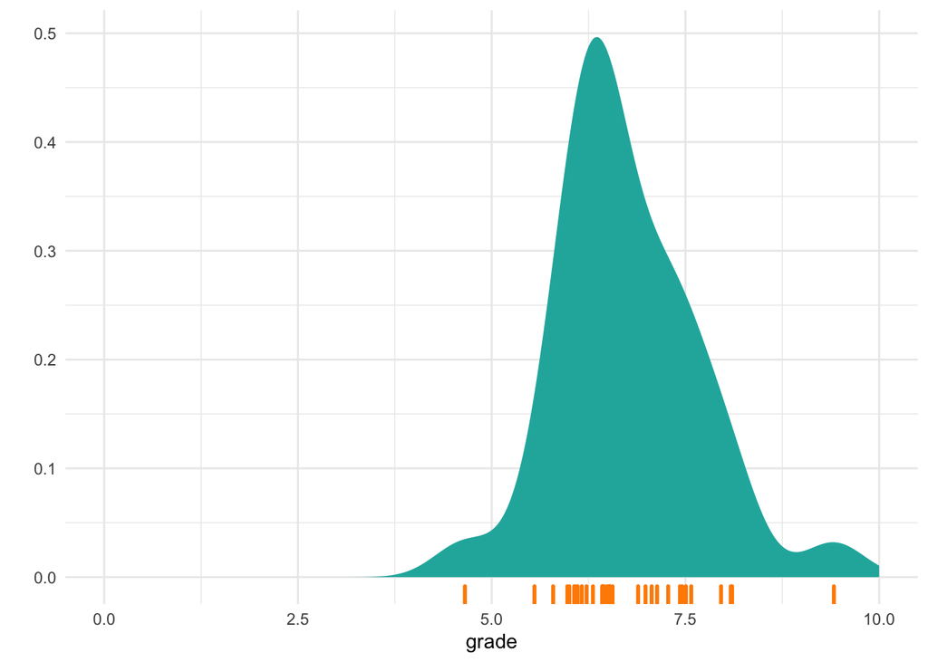

```r
gg_students %>%
  ggplot(aes(grade)) +
  geom_density(fill = "light seagreen", colour = NA) +
  geom_rug(size = 1, colour = "darkorange") +
  theme_minimal() +
  labs(y = "") +
  xlim(0, 10)
```

### Boxplot

**10. Create a boxplot of student grades per programme in the `gg_students` dataset you made earlier: map the programme variable to the x position and the grade to the y position. For extra visual aid, you can additionally map the programme variable to the fill aesthetic.**

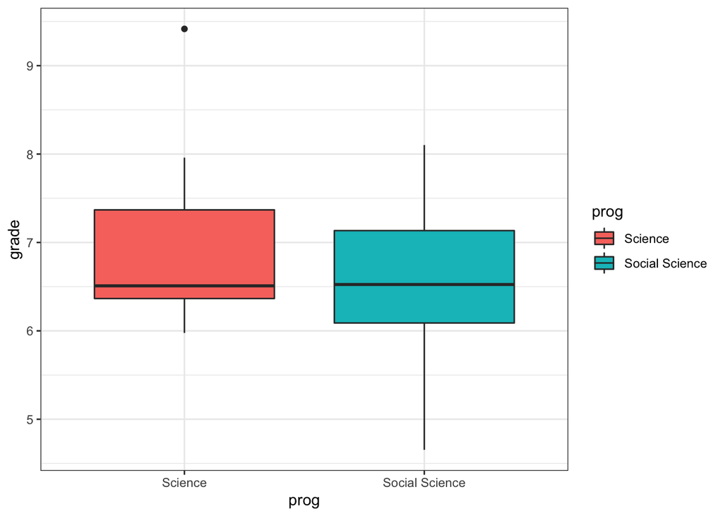

```r
gg_students %>%
  ggplot(aes(prog, grade, fill = prog)) +
  geom_boxplot() +
  theme_bw()
```

**11. What do each of the horizontal lines in the boxplot mean? What do the vertical lines (whiskers) mean?**

Horizontal lines:

- 25th percentile (the bottom line)
- Median (the middle line)
- 75th percental (the top line)

Vertical whiskers:

Boxplot whiskers represent the largest and smallest value that is within 1.5 * IQR distance from the IQR. Data beyond these extensions are outliers.

### Two densities

**12. Comparison of distributions across categories can also be done by adding a fill aesthetic to the density plot you made earlier. Try this out. To take care of the overlap, you might want to add some transparency in the geom_density() function using the alpha argument.**

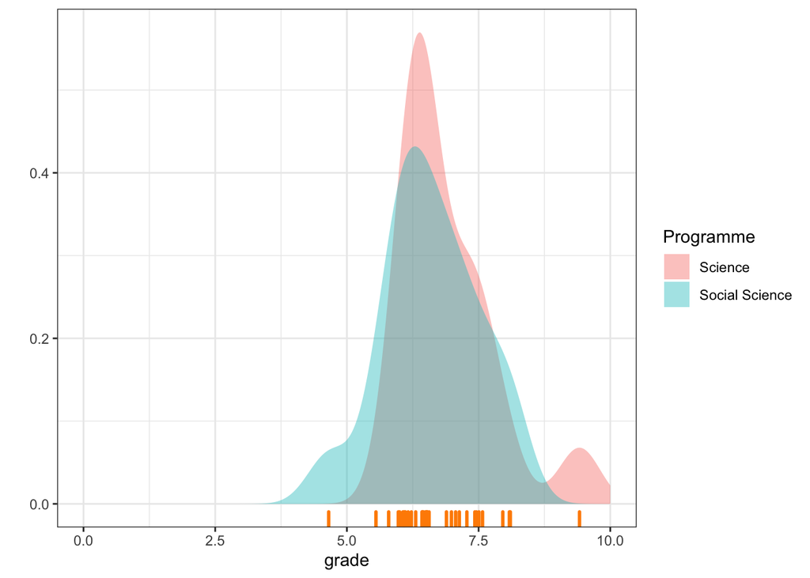

```r
gg_students %>%
  ggplot(aes(grade, fill = prog)) +
  geom_density(alpha = .4, colour = NA) +
  geom_rug(size = 1, colour = "darkorange") +
  theme_bw() +
  labs(y = "", fill = "Programme") +
  xlim(0, 10)
```

### Bar plot

**13. Create a bar plot of the variable Years from the Hitters dataset.**

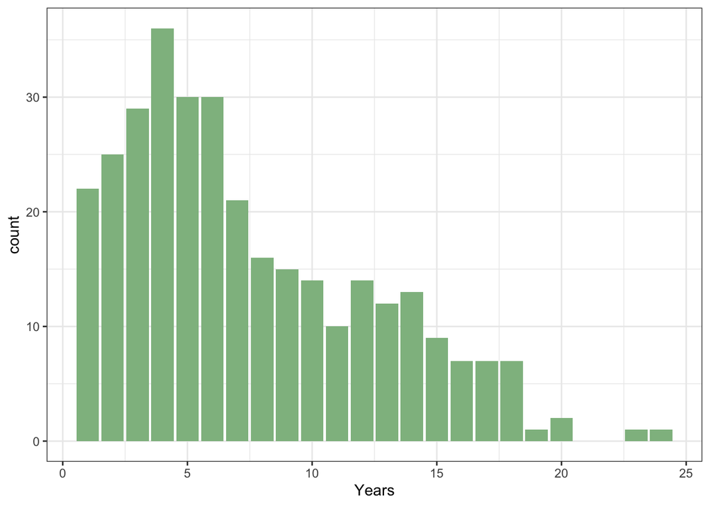

```r
Hitters %>%
  ggplot(aes(Years)) +
  geom_bar(fill = "darkseagreen") +
  theme_bw()
```

### Line plot

**14. Use `geom_line()` to make a line plot out of the first 200 observations of the variable `Volume` (the number of trades made on each day) of the `Smarket` dataset. You will need to create a `Day` variable using `mutate()` to map to the x-position. This variable can simply be the integers from 1 to 200. Remember, you can select the first 200 rows using `Smarket[1:200, ]`.**

I added some points too because I like it.

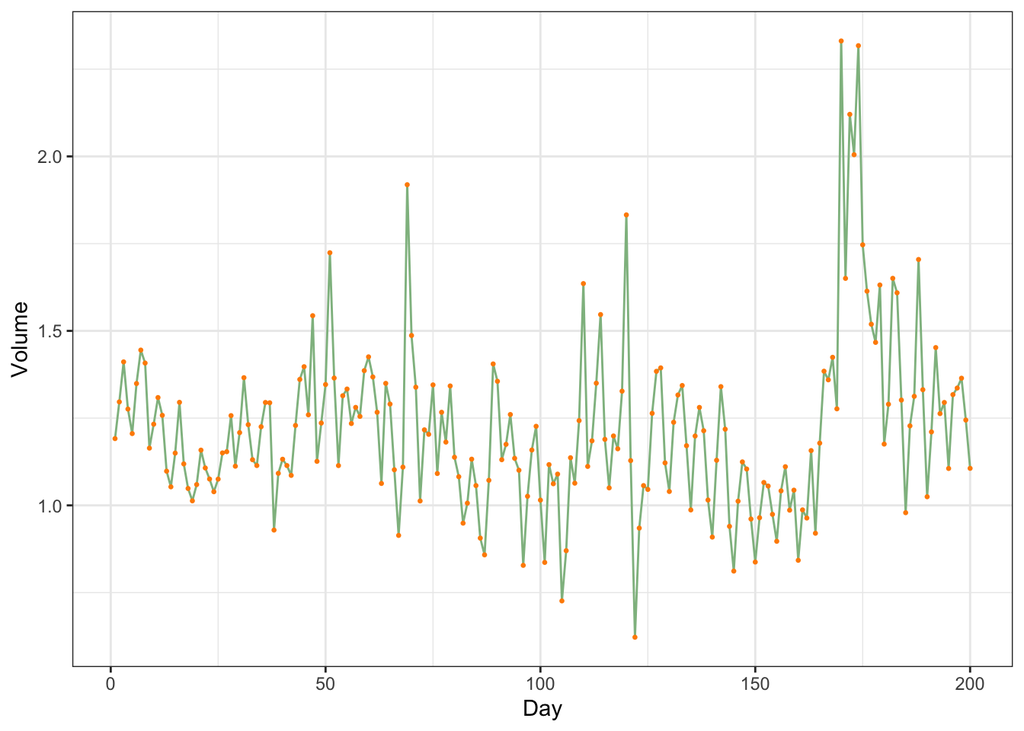

```r
Smarket[1:200,] %>%
  mutate(Day = 1:200) %>%
  ggplot(aes(Day, Volume)) +
  geom_line(color = "darkseagreen") +
  geom_point(colour = "darkorange", size = 0.5) +
  theme_bw()
```

**15. Give the line a nice colour and increase its size. Also add points of the same colour on top.**

Oh, I guess I got ahead of myself. I’ll try different colours.

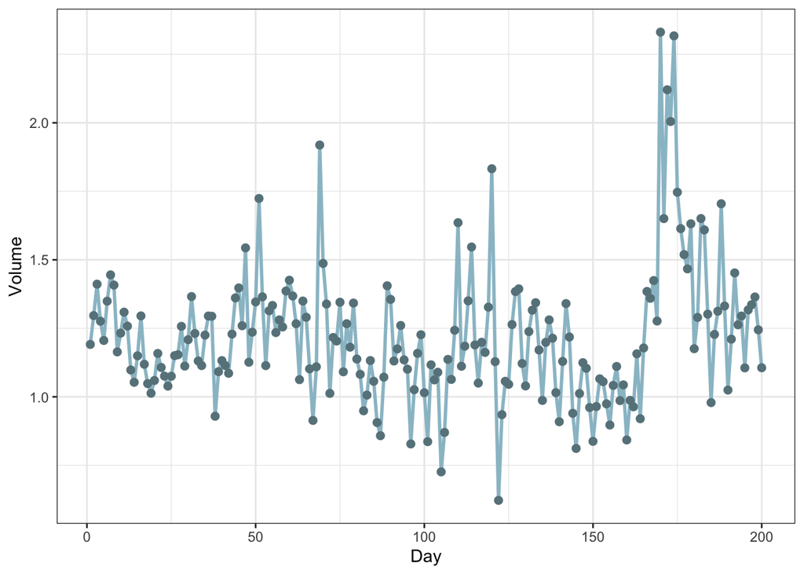

```r
Smarket[1:200, ] %>%
  mutate(Day = 1:200) %>%
  ggplot(aes(Day, Volume)) +
  geom_line(colour = "lightblue3", size = 1) +
  geom_point(colour = "lightblue4", size = 2) +
  theme_bw()
```

**16. Use the function which.max() to find out which of the first 200 days has the highest trade volume and use the function max() to find out how large this volume was.**

```r
# Highest trade volume
which.max(Smarket[1:200, ]$Volume)
```

```
## [1] 170
```

```r
# Volume is this large
max(Smarket[1:200, ]$Volume)
```

```
## [1] 2.33083
```

**17. Use `geom_label(aes(x = your_x, y = your_y, label = "Peak volume"))` to add a label to this day. You can use either the values or call the functions. Place the label near the peak!**

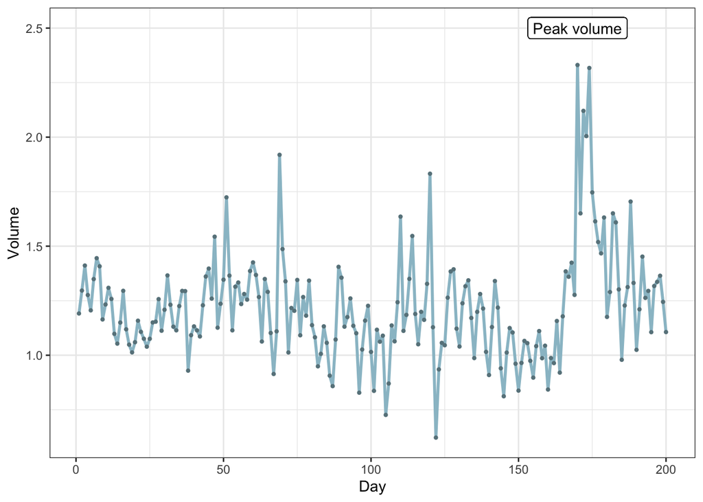

```r
Smarket[1:200, ] %>%
  mutate(Day = 1:200) %>%
  ggplot(aes(Day, Volume)) +
  geom_line(colour = "lightblue3", size = 1) +
  geom_point(colour = "lightblue4", size = 0.8) +
  geom_label(aes(x = 170, y = 2.5, label = "Peak volume")) +
  theme_bw()
```

### Faceting

**18. Create a data frame called baseball based on the Hitters dataset. In this data frame, create a factor variable which splits players’ salary range into 3 categories. Tip: use the filter() function to remove the missing values, and then use the cut() function and assign nice labels to the categories. In addition, create a variable which indicates the proportion of career hits that was a home run.**

```r
baseball <- Hitters %>%
  filter(!is.na(Salary)) %>%
  mutate(SalaryRange = cut(Salary, breaks = 3,
                              labels = c("low", "med", "high")),
         PropHomeRun = CHmRun/CHits)

# Look at it
baseball
```

```
##                    AtBat Hits HmRun Runs RBI Walks Years CAtBat CHits CHmRun
## -Alan Ashby          315   81     7   24  38    39    14   3449   835     69
## -Alvin Davis         479  130    18   66  72    76     3   1624   457     63
## -Andre Dawson        496  141    20   65  78    37    11   5628  1575    225
## -Andres Galarraga    321   87    10   39  42    30     2    396   101     12
## -Alfredo Griffin     594  169     4   74  51    35    11   4408  1133     19
## -Al Newman           185   37     1   23   8    21     2    214    42      1
## -Argenis Salazar     298   73     0   24  24     7     3    509   108      0
## -Andres Thomas       323   81     6   26  32     8     2    341    86      6
## -Andre Thornton      401   92    17   49  66    65    13   5206  1332    253
## -Alan Trammell       574  159    21  107  75    59    10   4631  1300     90
## -Alex Trevino        202   53     4   31  26    27     9   1876   467     15
## -Andy VanSlyke       418  113    13   48  61    47     4   1512   392     41
## -Alan Wiggins        239   60     0   30  11    22     6   1941   510      4
## -Bill Almon          196   43     7   29  27    30    13   3231   825     36
## -Buddy Bell          568  158    20   89  75    73    15   8068  2273    177
## -Buddy Biancalana    190   46     2   24   8    15     5    479   102      5
## -Bruce Bochy         127   32     8   16  22    14     8    727   180     24
## -Barry Bonds         413   92    16   72  48    65     1    413    92     16
## -Bobby Bonilla       426  109     3   55  43    62     1    426   109      3
## -Bob Brenly          472  116    16   60  62    74     6   1924   489     67
## -Bill Buckner        629  168    18   73 102    40    18   8424  2464    164
## -Brett Butler        587  163     4   92  51    70     6   2695   747     17
## -Bob Dernier         324   73     4   32  18    22     7   1931   491     13
## -Bo Diaz             474  129    10   50  56    40    10   2331   604     61
## -Bill Doran          550  152     6   92  37    81     5   2308   633     32
## -Brian Downing       513  137    20   90  95    90    14   5201  1382    166
## -Billy Hatcher       419  108     6   55  36    22     3    591   149      8
## -Brook Jacoby        583  168    17   83  80    56     5   1646   452     44
## -Bob Kearney         204   49     6   23  25    12     7   1309   308     27
## -Bill Madlock        379  106    10   38  60    30    14   6207  1906    146
## -Bob Melvin          268   60     5   24  25    15     2    350    78      5
## -BillyJo Robidoux    181   41     1   15  21    33     2    232    50      4
## -Bill Schroeder      217   46     7   32  19     9     4    694   160     32
## -Chris Bando         254   68     2   28  26    22     6    999   236     21
## -Chris Brown         416  132     7   57  49    33     3    932   273     24
## -Carmen Castillo     205   57     8   34  32     9     5    756   192     32
## -Chili Davis         526  146    13   71  70    84     6   2648   715     77
## -Carlton Fisk        457  101    14   42  63    22    17   6521  1767    281
## -Curt Ford           214   53     2   30  29    23     2    226    59      2
```

[output cut: 737 more lines]

```
## -Ted Simmons        500.000         N         low 0.100749376
## -Tim Teufel         277.500         N         low 0.087323944
## -Tim Wallach        750.000         N         low 0.142671855
## -Vince Coleman      160.000         N         low 0.003236246
## -Von Hayes         1300.000         N         med 0.091633466
## -Vance Law          525.000         N         low 0.072438163
## -Wally Backman      550.000         N         low 0.011857708
## -Wade Boggs        1600.000         A         med 0.032719836
## -Will Clark         120.000         N         low 0.094017094
## -Wally Joyner       165.000         A         low 0.127906977
## -Willie McGee       700.000         N         low 0.039702233
## -Willie Randolph    875.000         A         med 0.025810721
## -Wayne Tolleson     385.000         A         low 0.016166282
## -Willie Upshaw      960.000         A         med 0.113185531
## -Willie Wilson     1000.000         A         med 0.020590254
```

**19. Create a scatter plot where you map `CWalks` to the x position and the proportion you calculated in the previous exercise to the y position. Fix the y axis limits to (0, 0.4) and the x axis to (0, 1600) using `ylim()` and `xlim()`. Add nice x and y axis titles using the `labs()` function. Save the plot as the variable `baseball_plot`.**

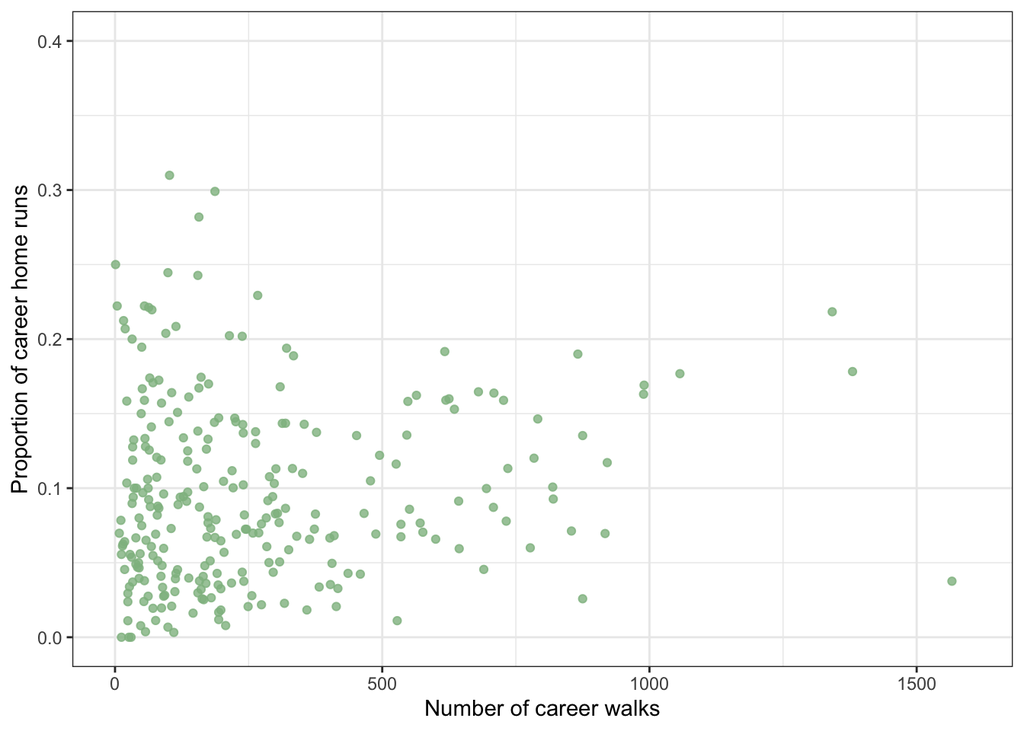

```r
baseball_plot <-
  baseball %>%
  ggplot(aes(CWalks, PropHomeRun)) +
  geom_point(color = "darkseagreen", alpha = 0.8) +
  ylim(0, 0.4) +
  xlim(0, 1600) +
  labs(y = "Proportion of career home runs", x = "Number of career walks") +
  theme_bw()

baseball_plot
```

**20. Split up this plot into three parts based on the salary range variable you calculated. Use the facet_wrap() function for this; look at the examples in the help file for tips.**

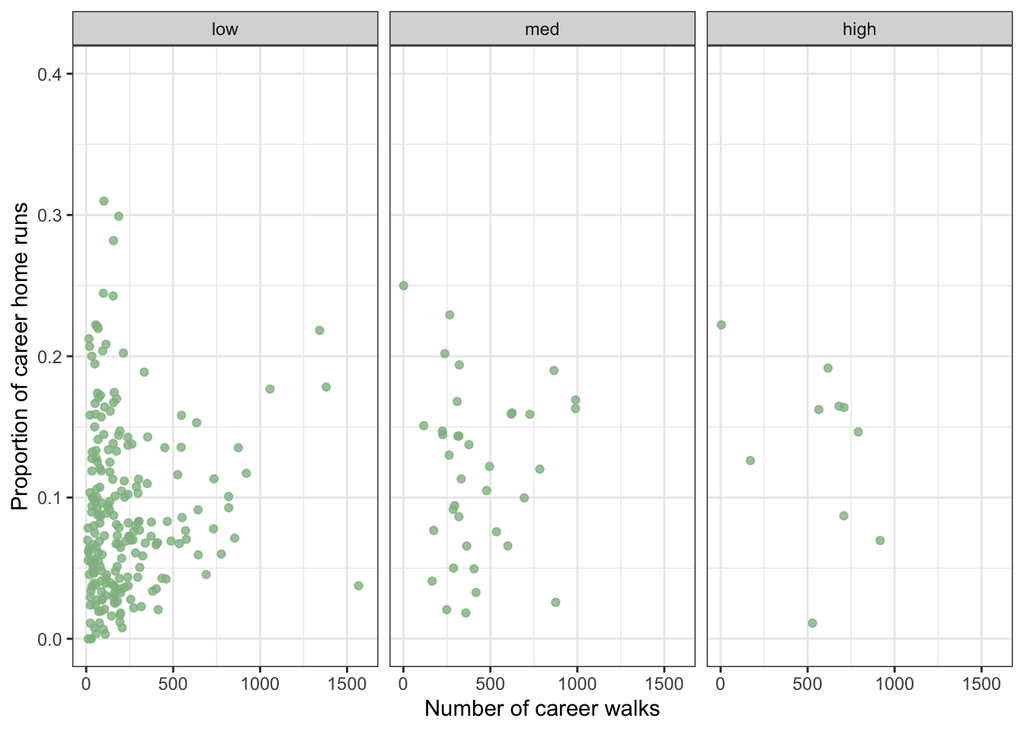

```r
baseball_plot +
  facet_wrap(~SalaryRange)
```

## Final exercise

**21. Create an interesting data visualisation based on the Carseats data from the ISLR package.**

```r
library(viridis)
```

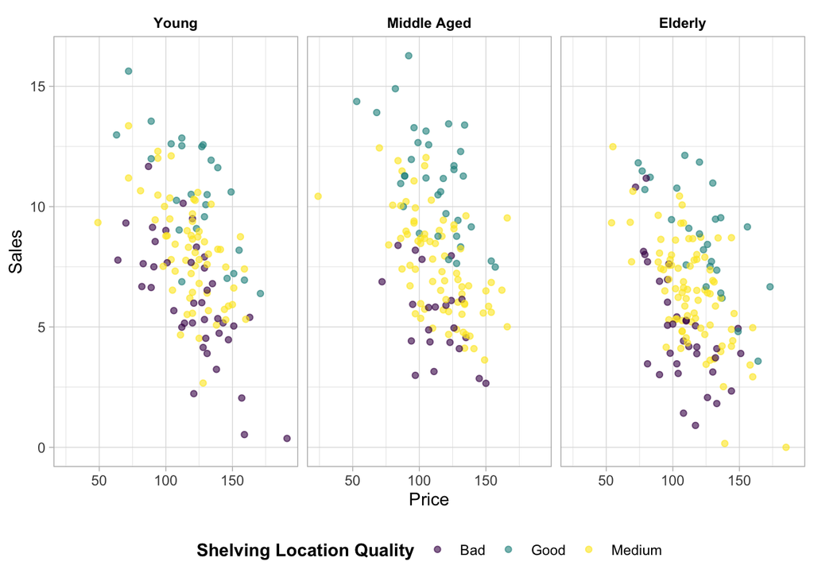

```r
Carseats %>%
  mutate(Age = cut(Age, breaks = 3, labels = c("Young", "Middle Aged", "Elderly"))) %>%
  ggplot(aes(Price, Sales, colour = ShelveLoc)) +
  geom_point(alpha = 0.6) +
  labs(colour = "Shelving Location Quality") +
  theme_light() +
  theme(legend.position =  "bottom",
        legend.title = element_text(face = "bold"),
        strip.background = element_rect(fill = NA),
        strip.text = element_text(colour = "black", face = "bold")) +
  scale_color_viridis(discrete=TRUE) +
  facet_wrap(~Age)
```